# Jianguo Meeting Notes

## Overview of what we're trying to do

- Take in functions definitions in some language (recursive equations; haskell; scheme; etc.)
- Output equations relating those definitions, using universally-quantified variables, checked via random testing. These could be sent to a theorem prover afterwards, but we're mostly concerned with the conjectures.

### Example: Peano natural numbers

```
Z : ℕ           Note, 'Z' is just a name, representing 0; it's not a variable
S : ℕ → ℕ,      "Successor", i.e. ∀n : ℕ, S(n) : ℕ
```

We can define functions on these, e.g.

```
 plus(Z,    y) = y                            Standard recursive definition of +
 plus(S(x), y) = S(plus(x, y))

times(Z,    y) = Z                            Standard recursive definition of ×
times(S(x), y) = plus(y, times(x, y))
```

We can write equations involving these, e.g.

```
∀x : ℕ, plus(Z, x) = x                          i.e. 0 + x = x
∀x : ℕ, plus(x, Z) = x                          i.e. x + 0 = x
∀x : ℕ, plus(x, x) = times(S(S(Z)), x)          i.e. x + x = 2 × x
∀x : ℕ, ∀y : ℕ, plus(x, y) = plus(y, x)         i.e. x + y = y + x
...
```

We don't want *all* equations; e.g. `plus(Z, Z) = Z`, `plus(Z, plus(Z, Z)) = Z`, etc. Only "interesting" ones.

### Existing Approach

We have a system which will do this (QuickSpec), but it is exhaustive and slow.

[figure not shown]

Given definitions for functions `f`, `g`, `h`, etc., QuickSpec will add some variables, say `x`, `y` and `z`, then enumerate all terms in a simple grammar of function application involving these functions and variables; stopping when it reaches a predetermined level of nesting (3 by default). For the above functions, terms would include `f`, `g(x, f(y))`, `h(h(x), f(h))`, etc. (depending on the input and output types of `f`, `g` and `h`).

We then pick a random value for the variables (`x`, `y` and `z`), substitute these values into the terms, run them as programs and compare the results. For any which gave equal results, we pick new random values for the variables and compare them again, and so on. If there are any terms which gave equal results across 1000 random substitutions, we output a conjecture that the terms are equal.

This approach is exhaustive, since it produces every possible term. That means it's guaranteed to find an equation if it exists; but it will also perform a lot of work comparing terms which we may consider unrelated. For example, if we give the system definitions of `plus`, `times` and `parseHTTPHeader`, it will treat them all as black boxes, despite the fact that `plus` and `times` are very similar (compare their definitions above).

#### Aside: Generating New Functions

Jianguo observed that if we're enumerating terms in the language, won't we generate new function definitions, in addition to those we're given?

This is interesting. The naive answer is that we won't generate new functions, since we're only enumerating *function applications*. Our language is a form of λ-calculus, with a grammar something like this (details vary, e.g. between SMT-LIB, Haskell, Isabelle, etc.):

```
term := <app> | <func> | <var>

app  := ( <term> ) ( <term> )

func := λ <var> <term>

var  := a | b | c | ...
```

Our input is a set of pairs, each one containing a unique name (e.g. `plus`) and a `<func>` (e.g. a λ-calculus encoding of Peano addition). The grammar we use to generate terms is more limited:

```
term := <app> | <var>

app  := ( <term> ) ( <term> )

var  := f1 | f2 | f3 | ... | v1 | v2 | v3 | ...
```

Where the `f`s are the names in our input (e.g. `plus`), and the `v`s are variable names we add in at the start (3 for each type). Hence we can never generate new definitions, since we never use the `<func>` rule.

If we think a bit harder, it's actually very easy to end up defining new functions, if our inputs can *encode* function definitions! It's very easy to "embed" one functional language inside another, so it's common for APIs to be written as domain-specific languages (e.g. Parsec, miniKanren, etc.).

As a trivial example, it's well known that untyped λ-calculus can be encoded using only the S and K functions from combinatory logic:

```
S(x, y, z) = x(z, y(z))

K(x, y) = x
```

If we send these two simple definitions into our conjecture generators, the term generator will be systematically enumerating all computable functions!

So is this an issue, conceptually or practically? I'd say no in both cases. If the input domain encodes functions efficiently (i.e. with few symbols, like SK calculus terms), then we *will* generate (encoded) functions as part of the search, but that's arguably what we want, since that's what those functions "do". If the functions don't encode a way to define functions, or don't do so efficiently, then new functions won't be generated (either because they can't be expressed, or because the terms would be too big for the search to find, respectively); which, again, is arguably what we want.

### Proposed Improvements

We have two proposed improvements: both may improve speed, but reduce "quality".

Proposal one: split up the input into a number of smaller "buckets", and check each bucket separately. This introduces a couple of parameters: how many buckets to use, and how to distribute the definitions between them? As a rule of thumb, we'll use the square root of the number of definitions as the number of buckets; we'll distribute inputs uniformly, based on a (SHA256) hash of their names:

[figure not shown]

Proposal two: use the same approach of bucketing, but try to be smart about which definitions we group together by comparing the definitions themselves (consider the above example of `plus`, `times` and `parseHTTPHeader`).

We've implemented one particular algorithm to do this (Katya's "recurrent clustering" algorithm), but there could potentially be many more (e.g. using models like bag of words, latent semantic analysis, word2vec, etc.).

The two main questions we have are:

- How do we compare the performance of these systems, in terms of running time?
- How do we compare the "quality" of the outputs? Limiting searches to separate buckets means that we won't find equations involving functions from different buckets; how much of a problem is this?

### Benchmark Method

We have adapted a benchmark suite designed for testing the capability of theorem provers, to instead use as the ground truth for this exploration/conjecturing task.

The suite contains 343 benchmarks; each benchmark contains a single theorem, e.g. `x × (y + z) = (x × y) + (x × z)`, along with the datatypes and functions used in that theorem (in this example, a declaration of the type `ℕ` and definitions of the `+` and `×` functions). Ignoring duplicates, there are 269 function definitions. We can use these as our ground truth in two ways:

- Each benchmark theorem is "good", in the sense that a human bothered to write it down in a formal system and check whether theorem provers can prove it. We can assume theorems which *aren't* in the benchmarks are "bad" (and send patches to the benchmark suite otherwise!).
- Since each benchmark contains the definitions it uses, if we only have a subset of the definitions we can tell which theorems are still possible. This lets us:
  - Draw samples from the definitions, rather than using all of them (which would be far too slow).
  - Judge the quality of our bucketing methods, by seeing how many theorems we lose due to splitting up their dependencies into separate buckets.

We have a bunch of scripts to work with these benchmarks, to pool together definitions from multiple benchmarks, sample subsets of the definitions, translate the functions into various programming languages, find theorems admitted by a particular subset, etc.

## Comparing Runtimes

Our first hypothesis is that separating into buckets will be faster than searching everything together; although overheads may dominate when the number of definitions is small.

How can we measure this? We have chosen various sizes (5, 10, 15, etc.) and for each, we sample 30 subsets of that size from the benchmark definitions (drawn such that the dependencies of at least one theorem are included, but otherwise uniformly). We measure how long it takes to search each of these subsets: completely, bucketing with hashes, and bucketing based on similarity.

Our major question is, how can we compare these runtimes to show if there is any difference?

For example, here are runtimes (in seconds, on a logarithmic scale) for the baseline system (QuickSpec), running with sets of size 5:

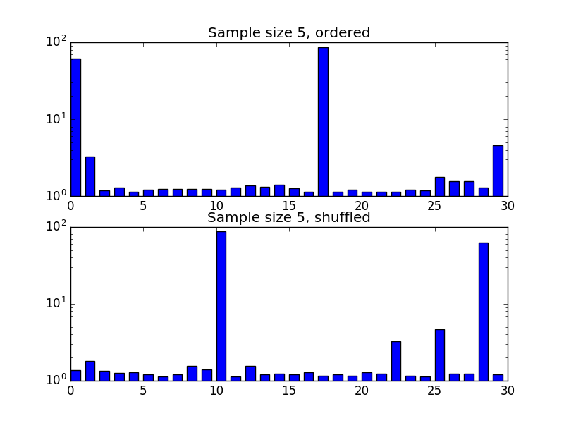

Each bar is for a different sample. The top bars are in the order they were executed, and show no trend compared to the shuffled bars beneath, indicating that each samples' run is independent (no effects from caching, etc.). Here are the same samples, run through our smart bucketing system (MLSpec) instead:

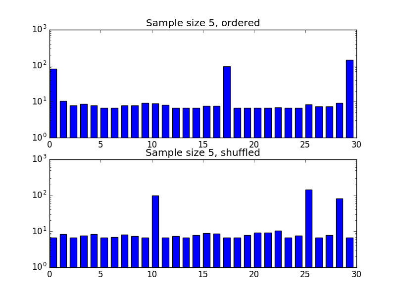

How can we compare these in a quantitative way? One observation is that the times don't seem to be normally distributed; they appear to follow a power law (many small values, a few large ones).

### Jianguo's Advice

Do not try to aggregate these runs together: any attempt to average them will be dominated by the few large values, and comparing across samples is apples to oranges.

Instead, calculate the *difference between two systems*, for each individual sample, known as a paired difference test. If we only have a few samples, we can use a Wilcoxon signed-rank test; for more than 10 samples with a non-zero difference, this converges towards a normal distribution, so a standard paired Z-test can be used instead; since we're running 30 iterations, we can use the latter. Our null hypothesis is that the average difference is zero.

This is valid even for non-normal data. It's also robust against timeouts:

- If both systems time out for some input, their difference is zero, so that sample gives *less* evidence for a difference between the systems.
- If one system times out and the other doesn't, the timeout sets a cap on how large the difference between them can be, and hence on how much evidence that sample can provide for a difference between the systems.
- If neither system times out, nothing special happens.

Hence the presence of timeouts cannot cause false positives; it just reduces our confidence in true positives.

We want to compare performance over a range of sample sizes (say, up to 100). It would be nice to have a graph of the speed difference, say comparing everything to QuickSpec, with the 95% confidence interval and mean, whose zero crossing is the point where the overheads become worth it.

Jianguo suggested maybe plotting the p-value/confidence against sample size; showing how confident we are that a system is faster, rather than giving a particular speedup factor. This doesn't seem like the nicest visualisation, since:

- p-value isn't an immediately obvious, easy to interpret value like speedup might be.
- p-value isn't a proxy for speed: we could be *very* confident that we're slightly better.

## Comparing Outputs

Existing systems (QuickSpec, HipSpec, IsaCoSy and IsaScheme) compare their results to theorems from the Isabelle theorem prover's standard library. They measure:

- Precision, defined as $\frac{Number of good theorems found}{Number of theorems found}$
- Recall, defined as $\frac{Number of good theorems found}{Number of good theorems possible}$

We're considering a similar approach, but using our benchmarks as a larger dataset than the existing ones, which only have about a dozen theorems.

### Jianguo's Advice

These definitions of precision and recall are different from those Jianguo is used to, e.g. in machine learning.

Instead, we might want to come up with a single numeric "score" (e.g. F-score, or some novel scoring function), then do the following:

- Define a cutoff value for this score, e.g. 0.8.
- Rank all results in order of their score.
- The positives are those with score higher than the cutoff, the negatives are those below.
- The true positives/false negatives are those whose output we consider to be good.
- The false positives/true negatives are those whose output we consider to be bad.

Think about possible ways that a result (equation) might get a high score, despite being subjectively bad. Likewise, think about ways that a good result might get a bad score.

Personally, I'm not too sure about introducing this approach. We don't want to reinvent all of the wheels, and the existing precision/recall tables seem like a reasonable thing to build upon. Jianguo's precision/recall measure is maybe more suited to something like a classifier.